## Database to Document with RMarkdown

Instructor: Benoît Parmentier

## The End of the Pipeline

The pipeline under construction begins with data, moves through processing, analysis and visualization, and typically ends by producing content for a final report.

RMarkdown offers the tantalizing opportunity to merge content and produce that final report as well.

## Objectives

1. Use the R and RMarkdown languages to script an entire pipeline in one file.
2. Connect the input of the pipeline to a database.
3. Publish the output of the pipeline on GitHub Pages.

## RMarkdown

RMarkdown, like R itself, is both a language and an interpreter.

**Language:** a set of special characters and structural rules that accompany text as instructions to the interpreter

**Interpreter:** software that converts the text and instructions into a formatted document of specified type

## RMarkdown + `knitr`

RMarkdown calls the `knitr` package to excute everything fenced off as R script within an RMarkdown document, and then selectively includes results in the formatted document.

## Seeing is believing

Open the handout `lesson-7.Rmd`, which is the RMarkdown source for this presentation.

```r
vals <- c(4, 5, 6)
data <- data.frame(counts = vals)
data
```

```
##   counts
## 1      4
## 2      5
## 3      6
```

The print out of `data` is not in the source; it was "knit" into the final document.

## Worksheet

The RMarkdown source for this lesson, with portions replaced by `...` that are for you to repair, is your worksheet. The goal of each exercise is to write the source for the generated slide.

## Exercise 1

To compare the output the output of your worksheet to this slide, press the knit button in RStuido

## RMarkdown Syntax

A RMarkdown document must begin with header content (or nothing) between a pair of lines containing only `---`. The header specifies the type of document to create and other configurations:

```
---
output:
  html_document:
    self-contained: true
---
```

## RMarkdown Syntax

A line beginning with `#` symbols denotes headers of varying size

```
# The Biggest Heading
## The Second Biggest Heading
### The Third Biggest Heading
```

Block quotes, like this syntax example, are produced by indenting text 4 spaces. Text within a block quote is displayed verbatim (as above). Without indenting, formatting happens (as follows).

## The Biggest Heading

## The Second Biggest Heading

### The Third Biggest Heading

## RMarkdown Syntax

Separate text with pipes ("|") to indicate columns of a table and hyphens ("-") to mark the beginning of a table or to separate the header.

```
id | treatment
---|----------
1  | control
2  | exclosure
```

| id | treatment |
| --- | --- |
| 1 | control |
| 2 | exclosure |

## RMarkdown Syntax

Embedding text between pairs of special characters induces some simple formatting. For example, use * for *italics* and ** for **bold**.

## Exercise 2

## RMarkdown Syntax

Many more elements of markdown await discovery:

1. lists
2. [links](http://lmgtfy.com/?q=markdown+cheat+sheet)
3. … but let's move on to embedding R code!

## Code chunks

A R "code chunk"" is fenced with `` ```{r} `` above and `` ``` `` below the code.

> ```{r}  
> vals <- c(4, 5, 6)  
> ```

That's three backtick characters, found next to the "1" on QWERTY keyboards.

## Code chunks

Options, such as `include = FALSE` or `eval = FALSE`, specified at each chunk will override the defaults. They are place after the `r` and optional chunk name at the top of each code chunk.

For example:

> ```{r assign_vals, echo = FALSE}  
> vals <- c(4, 5, 6)  
> ```

will (by default) evaluate the content but not show the code in the document.

## Code chunks

A value defined in one code chunk, i.e.

```r
vals <- c(4, 5, 6)
```

is accessible in another:

```r
vals + 1
```

```
## [1] 5 6 7
```

## Exercise 3

## Construct the Pipeline

If your entire pipeline can be scripted in R, then you could simply paste a long script into a single code chunk before moving on to generating content (e.g. tables or plots) for the final document.

It's better to modularize your script: break it into separate chunks that perform discrete tasks and let RMarkdown cache intermediate results.

## My Portal Study

Finally, write up your analysis of the data. Include nicely formatted tables of fitted models.

|  | *Dependent variable:* |
| --- | --- |
|  | count |
| weight | -0.388 |
|  | (0.786) |
| Constant | 98.921* |
|  | (47.516) |
| Observations | 15 |
| R<sup>2</sup> | 0.018 |
| Adjusted R<sup>2</sup> | -0.057 |
| Residual Std. Error | 126.860 (df = 13) |
| F Statistic | 0.244 (df = 1; 13) |
| *Note:* | p<0.1; p<0.05; p<0.01 |

## My Portal Study

Adjust your figures to fit nicely in the output document, but don't expect too much.

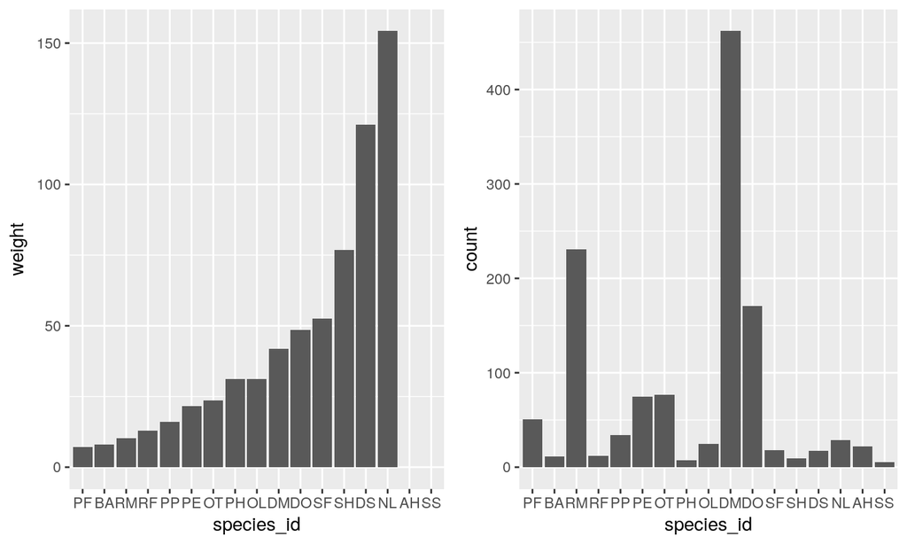

## Publish to GitHub Pages

Your handouts repository on GitHub includes a free web hosting service known as GitHub Pages. Publish your worksheet there with the following steps.

- Copy the resulting HTML file to 'docs/index.html'
- Notice the essential (but empty) 'docs/_config.yml' file
- Commit & Push
- Enable GitHub Pages: Settings > master/docs folder

## Solutions

## Solution 1

To compare the output of your worksheet to this slide, press the "Knit" button in RStudio.

## Solution 2

| charcter | format |
| --- | --- |
| * | *italics* |
| ** | **bold** |
| ^ | super<sup>script</sup> |
| ~~ | strikethrough |

## Solution 3

```r
animals
```

```
## # Source:   table<animals> [?? x 9]
## # Database: postgres 9.6.3 [rpoudel@localhost:5432/portal]
##       id month   day  year plot_id species_id   sex hindfoot_length weight
##    <int> <int> <int> <int>   <int>      <chr> <chr>           <int>  <int>
##  1     2     7    16  1977       3         NL     M              33     NA
##  2     3     7    16  1977       2         DM     F              37     NA
##  3     4     7    16  1977       7         DM     M              36     NA
##  4     5     7    16  1977       3         DM     M              35     NA
##  5     6     7    16  1977       1         PF     M              14     NA
##  6     7     7    16  1977       2         PE     F              NA     NA
##  7     8     7    16  1977       1         DM     M              37     NA
##  8     9     7    16  1977       1         DM     F              34     NA
##  9    10     7    16  1977       6         PF     F              20     NA
## 10    11     7    16  1977       5         DS     F              53     NA
## # ... with more rows
```